# Performance of Bluetooth gamepads

Thomas Schaffter, thomas.schaffter@sagebionetworks.org

September 08, 2020

```r
rm(list=ls())

library(ggplot2)
library(dplyr)
library(tidyr)
```

# Overview

- remove jstest rows with type 129 and 130

Here are the questions that we want to answer:

- Use Built-in Bluetooth or ASUS USB-BT400 USB Adapter
- Use USB 2.0 or 3.0 port for ASUS USB-BT400 USB Adapter
- Use Xbox One S Controller or PS4 Controller
- Does jstest captures all the Bluetooth packages received from the controller?

# Manual preparation of the data

## jstest files

These lines are manually removed from the jstest dump files (`*_jstest.txt`).

- First 4 lines (general info)
- Following lines with event type 129 and 130 (list of all buttons)

## hcidump files

`hcidump` generates several lines for each package received. For each package, we only keep the line that includes the keyword “ACL data”. For example,

```
grep "ACL data" hci0_xbox_front_hcidump.txt > hci0_xbox_front_hcidump_.txt
```

# Data

We define all the parameters of the experiments.

```r
hcis <- list(
  hci0 = list(
    name = "Raspberry Pi 4",
    mac = "DC:A6:32:8A:DA:FD",
    bt_version = "5.0"
  ),
  hci1 = list(
    name = "ASUS USB-BT400",
    mac = "5C:F3:70:94:05:7A",
    bt_version = "4.0"
  )
)

devices <- list(
  xbox = list(
    name = "Xbox One S Controller",
    bt_version = "4.2",
    color = "#107C10"  # Xbox green
  ),
  ps4 = list(
    name = "PS4 Controller",
    bt_version = "4.0",
    color = "#003791"  # PS dark blue
  )
)

locations <- list(
  front = list(
    name = "Front",
    description = "In front of the TV stand"
  )
  # back = list(
  #   name = "Back",
  #   description = "Behind the TV stand"
  # )
)

phases <- list(
  list(start = 0, end = 60),
  list(start = 120, end = 180),
  list(start = 240, end = 300)
)

data_dir <- "/data/0"
t_max <- 300

# colors
slate_gray <- "#3A3A3A"
colors <- list(
  "#118df0",  # blue
  "#f8aa27",   # orange
  "#f35f5f"  # red
)
```

Helper functions

```r
# Reads Bluetooth data generated by my Bash script.
read_bt_data <- function(filename) {
  read.table(file = filename, sep = '\t', header = TRUE)
}

# Reads jstest files.
# Note: Here we use our own timestamp generated with `ts '%s'`. The timestamp
#       generated internally by `jstest` is the number of ms elapsed since the
#       start of the system.
read_jstest_data <- function(filename) {
  df <- read.table(text = gsub(",", "", readLines(filename)))
  data.frame(
    time = df$V1,
    event_type = df$V4,
    event_number = df$V8,
    event_value = df$V10
  )
}

# Reads hcidump data.
read_hcidump_data <- function(filename) {
  df <- read.table(file = filename, sep = ' ', header = FALSE)
  data.frame(
    time = df$V1
  )
}
```

We read the data and apply the following transformation to them for each experiment.

- Set time to 0 when the first controller button is pressed
- Keep only data between 0 and 300 seconds
- Start HCI RX and TX bytes at 0 bytes (bt data)

```r
# generate all the combinations of parameters
experiments <- expand.grid(
  hci = names(hcis),
  device = names(devices),
  location = names(locations),
  stringsAsFactors = FALSE
)

# create experiment names
experiment_names <- experiments %>%
  unite(x, names(experiments), sep = "_", remove = TRUE) %>%
  pull(x)

# read and transform data
data <- lapply(1:nrow(experiments), function(i) {
  e <- experiments[i,]

  # read raw data
  bt = read_bt_data(file.path(data_dir, paste(
    e$hci, e$device , e$location, "bt.tsv", sep = "_"
  )))
  js = read_jstest_data(file.path(
    data_dir,
    paste(e$hci, e$device , e$location, "jstest.txt", sep = "_")
  ))
  hcidump = read_hcidump_data(file.path(
    data_dir,
    paste(e$hci, e$device , e$location, "hcidump_.txt", sep = "_")
  ))

  # set time to 0 when pressed first controller button
  t0 <- js$time[1]
  bt$time <- bt$time - t0
  js$time <- js$time - t0
  hcidump$time <- hcidump$time - t0

  # keep bt data collected after pressing the first button until the end of the
  # experiment defined by t_max
  bt <- subset(bt, time >= 0 & time <= t_max)
  js <- subset(js, time >= 0 & time <= t_max)
  hcidump <- subset(hcidump, time >= 0 & time <= t_max, drop = FALSE)

  # start HCI RX and TX bytes at 0 bytes
  bt$hci.rx.bytes <- bt$hci.rx.bytes - bt$hci.rx.bytes[1]
  bt$hci.tx.bytes <- bt$hci.tx.bytes - bt$hci.tx.bytes[1]

  list(bt = bt, js = js, hcidump = hcidump)
})

# name data
names(data) <- experiment_names
```

We create a second representation of the data after applying the following transformations:

- bt data: keep only numeric and variables that may change over time
- js data: count the number inputs per second
- hcidump data: count the number of packets received per second

We then pivot and combine these data to make it easier to plot them.

```r
data_ <- do.call(rbind, lapply(1:nrow(experiments), function(i) {
  e <- experiments[i,]
  name <- paste(e$hci, e$device, e$location, sep = "_")
  d <- data[[name]]

  # transform, pivot and combine data
  df <- bind_rows(
    d$bt %>%
      select_if(is.numeric) %>%
      select(-c("hci.bluetooth.version", "dev.0.bluetooth.version")) %>%
      pivot_longer(!time, names_to = "name", values_to = "value"),

    d$js %>%
      group_by(time) %>%
      summarise(n_inputs = length(time), .groups = 'drop') %>%
      pivot_longer(!time, names_to = "name", values_to = "value"),

    d$hcidump %>%
      group_by(time) %>%
      summarise(n_packets = length(time), .groups = 'drop') %>%
      pivot_longer(!time, names_to = "name", values_to = "value")
  )

  # append experiment parameters
  df$hci <- e$hci
  df$device <- factor(e$device, levels = c(names(devices)))
  df$location <- e$location

  df
}))
```

# Analysis

All the properties

```r
cat(sort(unique(data_$name)), sep="\n")
```

```
dev.0.lq
dev.0.rssi
dev.0.tpl
hci.rx.acl
hci.rx.bytes
hci.rx.errors
hci.rx.events
hci.rx.sco
hci.tx.acl
hci.tx.bytes
hci.tx.commands
hci.tx.errors
hci.tx.sco
n_inputs
n_packets
```

```r
property_limits = list(
  n_inputs = c(0, max(subset(data_, name == "n_inputs")$value)),
  n_packets = c(0, max(subset(data_, name == "n_packets")$value))
)

property_axis_title = list(
  hci.rx.bytes = "RX bytes"
)
```

## HCI data received over time

We show below the amount of bytes received by the built-in Bluetooth of the Raspberry Pi (`hdi0`, Bluetooth 5.0) and the ASUS Bluetooth adapter (`hci1`, Bluetooth 4.0). The ASUS adapter is USB 2.0 and connected to a port UBS 2.0 of the Raspberry Pi 4. The ASUS adapter is advertised as supporting up to 3 Mbps (megabits per second).

One of the main differences between the Xbox One S and the PS4 controllers is that the Xbox controller only sends data when buttons are pressed while the PS4 controller constantly sends data. This may come from the built-in accelerometer and gyroscope of the PS4 controller that could be constantly streamed. Note that maintaining the PS4 controller still does not affect the amount of data received (data not shown).

The amount of data received by `hci0` and `hci1` is very different when using the Xbox controller. As we have observed that the controller only sends data when buttons are pressed, one reason could be that less buttons were pressed when collecting data for `hci1` than when doing so for `hci0`. We don’t have this information but we have the number of buttons pressed / inputs captured by `jstest`. However, if Bluetooth packets are lost, this would naturally translate into a lower number of inputs reported by `jstest`. A figure shown below reveals that the number of inputs received from the Xbox controller by`hci0` and `hci1` is indeed different, though the difference in the RX rate is smaller in the third repetition. Reproducing the entire experiments led to similar results where the RX rate is much lower when using `hci1` than `hci0`, therefore we can not discard the hypothesis that something else contributes to lower the RX rate when using `hci1`. At the same time, we show with the PS4 controller that we can successfully reproduce a similar number of inputs when using `hci0` and `hci1` (see below).

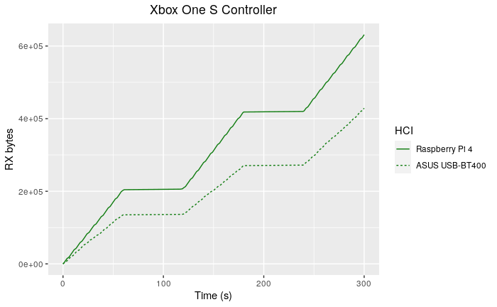

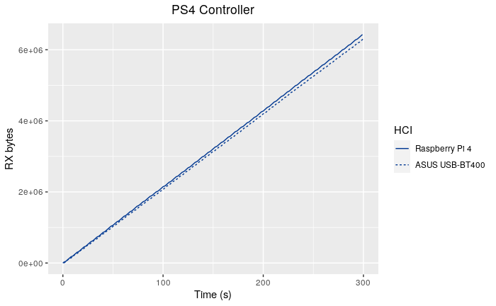

```r
property <- "hci.rx.bytes"

plots <- lapply(names(devices), function(dev) {
  # filter data
  d <- subset(data_, name == property & device == dev & location == "front")

  ggplot(d, aes(time, value, linetype = hci)) +
    geom_line(color = devices[[dev]]$color) +
    scale_linetype_discrete(name = "HCI", labels = sapply(hcis, "[[", "name")) +
    ggtitle(devices[[dev]]$name) +
    xlab("Time (s)") +
    ylab(property_axis_title[[property]]) +
    theme(plot.title = element_text(hjust = 0.5))
})

print(plots)
```

## Number of inputs reported by jstest

Here we report the number of inputs reported by `jstest` run on the Raspberry Pi. As briefly introduced above, the number of inputs shown by `jstest` may be different from the ground truth if the Bluetooth communication loose packets. We can already say that the number of RX and TX errors reported by `hci0` and `hci1` in our experiments is 0, so it does not seem that packets are lost.

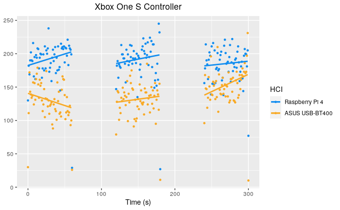

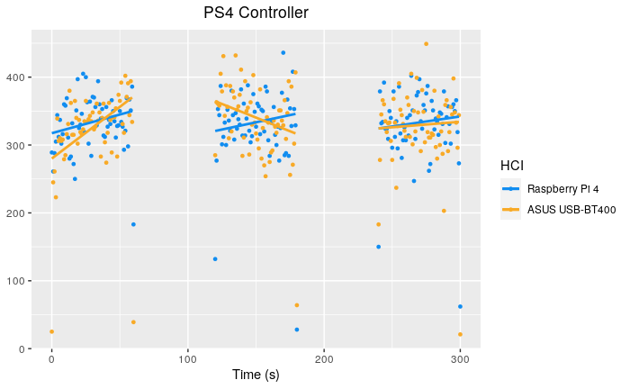

```r
property <- "n_inputs"

plots <- lapply(names(devices), function(dev) {
  # filter data
  d <- subset(data_, name == property & device == dev & location == "front")

  ggplot(d, aes(time, value, color = hci)) +
    geom_point(size = 1) +
    stat_smooth(method = lm, formula = 'y ~ x', se = FALSE, data=subset(d, time < phases[[1]]$end)) +
    stat_smooth(method = lm, formula = 'y ~ x', se = FALSE, data=subset(d, time >= phases[[2]]$start & time < phases[[2]]$end)) +
    stat_smooth(method = lm, formula = 'y ~ x', se = FALSE, data=subset(d, time >= phases[[3]]$start & time < phases[[3]]$end)) +
    scale_color_manual(name = "HCI", labels = sapply(hcis, "[[", "name"), values = colors) +
    ggtitle(devices[[dev]]$name) +
    xlab("Time (s)") +
    ylab(property_axis_title[[property]]) +
    theme(plot.title = element_text(hjust = 0.5))
})

print(plots)
```

## RX and TX errors

`hci0` and `hci1` do not report RT and TX errors when using the Xbox and PS4 controller.

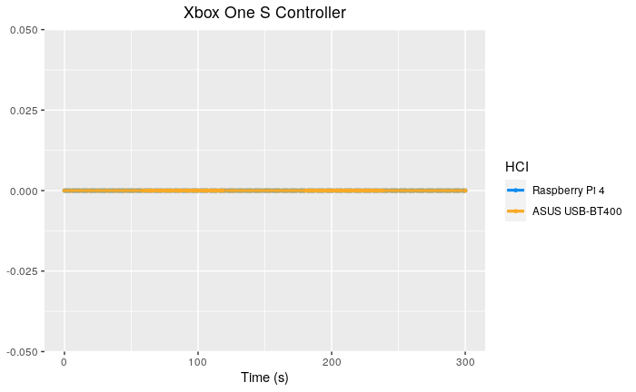

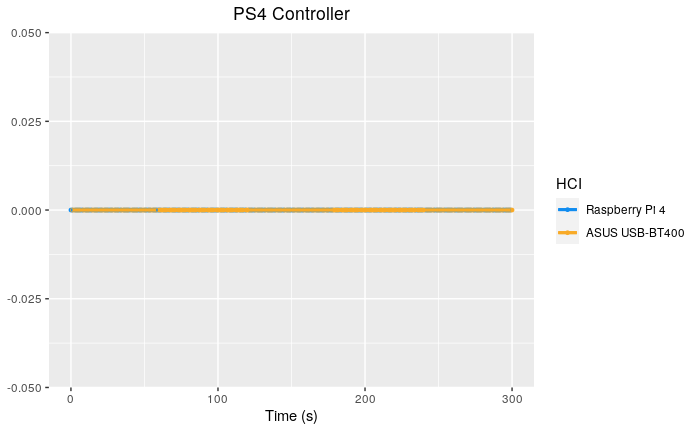

```r
property <- "hci.rx.errors"

plots <- lapply(names(devices), function(dev) {
  # filter data
  d <- subset(data_, name == property & device == dev & location == "front")

  ggplot(d, aes(time, value, color = hci)) +
    geom_point(size = 1) +
    stat_smooth(method = lm, formula = 'y ~ x', se = FALSE, data=subset(d, time < phases[[1]]$end)) +
    stat_smooth(method = lm, formula = 'y ~ x', se = FALSE, data=subset(d, time >= phases[[2]]$start & time < phases[[2]]$end)) +
    stat_smooth(method = lm, formula = 'y ~ x', se = FALSE, data=subset(d, time >= phases[[3]]$start & time < phases[[3]]$end)) +
    scale_color_manual(name = "HCI", labels = sapply(hcis, "[[", "name"), values = colors) +
    ggtitle(devices[[dev]]$name) +
    xlab("Time (s)") +
    ylab(property_axis_title[[property]]) +
    theme(plot.title = element_text(hjust = 0.5))
})

print(plots)
```

END for now

```r
property <- "n_inputs"
# property <- "n_packets"

d <- subset(data_, name == property &  location == "front")

ggplot(d, aes(time, value, color=device, shape=hci)) +
  geom_point(colour = slate_gray, size = 1) +
  stat_smooth(method = loess, formula = 'y ~ x', se = FALSE, data=subset(d, time < phases[[1]]$end)) +
  stat_smooth(method = loess, formula = 'y ~ x', se = FALSE, data=subset(d, time >= phases[[2]]$start & time < phases[[2]]$end)) +
  stat_smooth(method = loess, formula = 'y ~ x', se = FALSE, data=subset(d, time >= phases[[3]]$start & time < phases[[3]]$end)) +
  scale_y_continuous(limits = property_limits[[property]]) +
  scale_color_manual(name = "Receiver", values = sapply(devices, "[[", "color")) +
  scale_shape_discrete(name = "Device") +  # labels = sapply(hcis, "[[", "name")
  xlab("Time (s)") +
  ylab(property)
```

```r
# property <- "n_inputs"
property <- "n_packets"

d <- subset(data_, name == property &  location == "front")

ggplot(d, aes(time, value, color=device, shape=hci)) +
  geom_point(colour = slate_gray, size = 1) +
  stat_smooth(method = loess, formula = 'y ~ x', se = FALSE, data=subset(d, time < phases[[1]]$end)) +
  stat_smooth(method = loess, formula = 'y ~ x', se = FALSE, data=subset(d, time >= phases[[2]]$start & time < phases[[2]]$end)) +
  stat_smooth(method = loess, formula = 'y ~ x', se = FALSE, data=subset(d, time >= phases[[3]]$start & time < phases[[3]]$end)) +
  scale_y_continuous(limits = property_limits[[property]]) +
  scale_color_manual(name = "Receiver", values = sapply(devices, "[[", "color")) +
  scale_shape_discrete(name = "Device") +  # labels = sapply(hcis, "[[", "name")
  xlab("Time (s)") +
  ylab(property)
```

Number of inputs per second.

```r
js_inputs <- js %>%
  mutate(time_s = as.integer(time/1000)) %>%
  group_by(time_s) %>%
  summarise(n_inputs = length(time_s), .groups = 'drop')

ggplot(js_inputs, aes(time_s, n_inputs)) +
  geom_point(colour = slate_gray, size = 1) +
  stat_smooth(method = loess, formula = 'y ~ x', se = FALSE, data=subset(js_inputs, time_s <= 60)) +
  stat_smooth(method = loess, formula = 'y ~ x', se = FALSE, data=subset(js_inputs, time_s > 120 & time_s <= 180)) +
  stat_smooth(method = loess, formula = 'y ~ x', se = FALSE, data=subset(js_inputs, time_s > 240 & time_s <= 300)) +
  xlab("Time (s)") +
  ylab("Controller inputs")
```

```r
ggplot(bt, aes(time, dev.0.lq)) +
  geom_line()
ggplot(bt, aes(time, dev.0.rssi)) +
  geom_line()
ggplot(bt, aes(time, dev.0.tpl)) +
  geom_line()
```

```r
ggplot(bt, aes(time, hci.rx.bytes)) +
  geom_line()
ggplot(bt, aes(time, hci.rx.errors)) +
  geom_line()
ggplot(bt, aes(time, hci.rx.acl)) +
  geom_line()
ggplot(bt, aes(time, hci.rx.events)) +
  geom_line()
ggplot(bt, aes(time, hci.rx.sco)) +
  geom_line()
```

```r
ggplot(bt, aes(time, hci.tx.bytes)) +
  geom_line()
ggplot(bt, aes(time, hci.tx.errors)) +
  geom_line()
ggplot(bt, aes(time, hci.tx.acl)) +
  geom_line()
ggplot(bt, aes(time, hci.tx.commands)) +
  geom_line()
ggplot(bt, aes(time, hci.tx.sco)) +
  geom_line()
```

```r
bt
```